# 260-2017-12-01-exam-3-returned

2017-11-29 11:52:15

[figure not shown]

## The figure depicts the ????, one of the simplest circuits in the nervous system. It regulates ????.

- biceptual reflex; balance.
- myotatic/stretch reflex; muscle length/position.
- optokinetic reflex; muscle strength.
- Cartesian reflex; skeletal-muscular activity.

## This circuit has a/an ???? branch in which stretch receptors in intrafusal muscle fibers ???? the extrafusal muscle fibers from the *antagonist* muscle.

- polysynaptic; inhibit.
- autonomic; inhibit.
- monosynaptic; excite.
- monosynaptic; inhibit.

## Plutchik's biological approach to emotion focuses on an emotion's ???? and ????.

- subjective feelings; facial expressions.
- action tendencies (tendency to approach or avoid); valence (positive/negative).
- intensity; subjective feelings.
- influence on on reproduction; link to defense behavior.

## The serotonin hypothesis of depression suggests that ????.

- lowered 5-HT levels are part of the disorder.
- increased 5-HT levels are part of the disorder.
- lower ACh levels exacerbate the disorder's positive symptoms.
- higher DA levels are linked to the disorder's positive symptoms.

## The primary purpose of the *extrafusal* muscle fibers is to ????.

- Generate force.
- Inhibit the contraction of muscles.
- Sense tension/length.
- All of the above.

## Which of the following is true regarding fibers that link somatosensory receptors to the central nervous system?

- Fibers that are smallest in diameter conduct information the fastest.
- Thin fibers are generally the most heavily myelinated.
- Temperature-related information is conducted faster than touch-related information.
- Muscle spindle receptor axons are thickest and most heavily myelinated.

## All of the following are treatments for bipolar disorder :

- Lithium.
- Anticonvulsants.
- Antipsychotics.
- Dopamine agonists.

## All of the following regions in the cerebral cortex instantiate a topographic mapping of some part of the body *except*.

- Primary motor cortex (M1)
- Primary somatosensory cortex (S1)
- Primary auditory cortex (A1)
- Olfactory cortex

## The neurotransmitter ???? is released by \(\alpha\) motor neurons at the neuromuscular junction; this event leads to an ???? within the muscle fiber and eventually, muscle fiber contraction.

- Glutamate; EPSP.
- Acetylcholine; IPSP.
- Glutamate; IPSP.
- Acetylcholine; EPSP.

## Which of the following events must occur in order for neurotransmitter to be released from an axon's presynaptic terminal?

- Voltage-gated K+ channels must open to permit K+ to enter the cell.
- Voltage-gated Ca++ channels must open to permit Ca++ to enter the cell.
- Neurotransmitters must diffuse through the cytoplasm to the presynaptic membrane.
- None of the above.

## Gently rubbing an injury can produce some pain relief. This likely occurs because ????.

- Touch receptors activate inhibitory interneurons that inhibit ascending pain signals.
- Mechanically stimulating pain receptors causes them to sensitize.
- Mechanically stimulating pain receptors causes the release of capsaicin.
- Touch receptor stimulation makes pain signals propagate faster.

## For the next three (3) questions match the correct label to the letters in the figure below.}

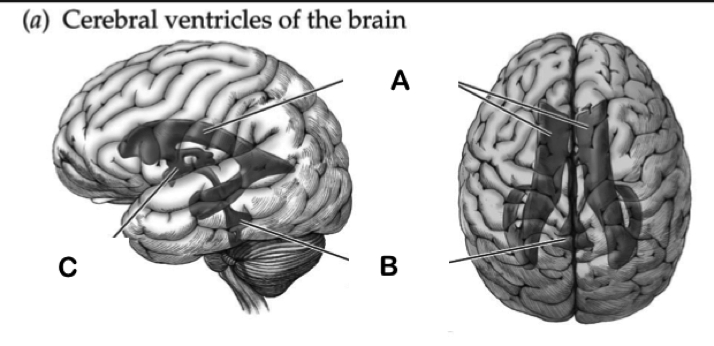

### Third Ventricle

### Lateral Ventricle

### Fourth Ventricle

## ???? is a preventable (and treatable) birth defect characterized by a failure in the closure of ???? neural tube.

- Spina bifida; caudal
- Anencephaly; caudal
- Spina bifida; rostral
- Anencephaly; rostral

## In most areas of the human cerebral cortex, synaptic density peaks ????.

- when the neural tube closes
- late in the fetal period
- late in adult life
- in early to middle childhood

## Diffusion Tensor Imaging (DTI) is a/an ???? MRI method that provides information about ????.

- functional; how neurotransmitters diffuse across the synaptic cleft
- functional; the blood oxygen-level dependent (BOLD) response
- structural; connectivity between brain areas
- structural; the branching structure of neuronal dendrites

## Schizophrenia is characterized by which of the following brain abnormalities?

- Increased size of ventricles.
- Reduced hippocampal volume.
- Accelerated gray matter loss.
- All of the above.

## Why might the dopamine (DA) hypothesis not provide a comprehensive explanation for schizophrenia?

- Changes in DA levels have not been shown to disturb memory function.
- The hypothesis cannot explain the strong developmental origins of the disease.
- Some drugs increase DA levels but reduce schizophrenic symptoms.
- DA antagonists only relieve the negative symptoms of schizophrenia.

## More recent theories about schizophrenia point to a disturbance in ????, one of the ???? common neurotransmitters released in the CNS.

- endorphins; least
- norepinephrine; most
- CO; least
- glutamate; most

## Woody Guthrie and his mother died of ????, a disease that targets the ????.

- Parkinson’s Disease; basal ganglia.
- Parkinson’s Disease; cerebellum.
- Huntington’s Disease; basal ganglia.
- Huntington’s Disease; cerebellum.

## Touch receptors enervating the skin on the ???? have especially *small* receptive fields.

- Face.
- Calf.
- Neck.
- Back.

## Perceptual sensitivity is *NOT* related to which of the following?

- Receptor density.
- Speed of propagation.
- Receptive field size.
- Size of the cortical area.

## In response to a typical environmental stressor, cortisol levels ????.

- involve activation of the SAM axis.
- rise, fall below baseline levels, then return.
- rise and stay elevated.
- rise then return to normal after a short period.

## The ???? in the ventral forebrain is the target of dopamine releasing neurons that originate in the ventral tegmental area of the ????; this forms a major pathway in the reward system.

- nucleus accumbens; midbrain
- dorsal striatum; thalamus
- superior colliculus; hippocampus
- amygdala; hypothalamus

## Indicate the letter of the lobe that corresponds to the location of each sensory or motor cortical area.

[figure not shown]

### Location of the primary somatosensory cortex.

### Location of the primary auditory cortex.

### Location of the primary motor cortex.

### Location of the primary visual cortex.

## The uterus consists of ???? muscle fibers that contract involuntarily in the presence of the hormone ????.

- Striated; cortisol.
- Striated; oxytocin.
- Smooth; oxytocin.
- Smooth; melatonin.

## The ???? of your smartphone is analogous to the pressure receptors in your skin.

- accelerometer
- cellular radio
- touch screen
- GPS transmitter

## Milner and Olds discovered that electrical stimulation of the medial forebrain bundle connecting the ???? and the ???? caused experimental animals to change their behavior in order to seek out ever more frequent stimulation.

- ventral tegmental area; nucleus accumbens
- hippocampus; amygdala
- temporal cortex; striatum
- hypothalamus; pituitary

## Based on what you know about SSRIs, Serotonin/Norepinephrine reuptake inhibitors (SNRIs) must act on presynaptic ???? and cause extracellular levels of these ???? to be increased.

- metabotropic receptors; hormones.
- ion pumps; amino acids.
- transporters; monoamines.
- Ionotropic receptors; indolamines.

## Spicy foods can seem `hot' even at room temperature because ????.

- thermoreceptors in the skin don't respond to temperature differences
- thermoreceptors in the skin also respond to certain chemical substances
- flavor involves the olfactory system and the gustatory system
- receptive fields for temperature overlap with those for flavor

## The nervous system contains specialized receptors for the psychologically active components of ???? and ????. This suggests some exogenous substances have psychological effects that mimic (to some degree) the effects of endogenous signaling systems.

- LSD; tobacco
- acetaminophen; L-Dopa
- cannabis; morphine
- phencylidine; lithium

## Elephants have high levels of dexterity (fine motor control) in their trunks. Somatosensory neurons in the trunk region of the elephant`s S1 are likely to have ????.

- Small receptive fields.
- Large receptive fields.
- Weak projections to corresponding regions of M1.
- Low levels of myelination.

## Which of these can be an effective treatment for Parkinson’s Disease?

- Dopamine Agonists
- NMDA Agonist
- Selective Serotonin Reuptake Inhibitors
- None of the above

## A somatosensory neuron's receptive field consists of ????.

- the skin between cutaneous receptor dendrites
- the region of the skin that influences the neuron's firing when stimulated
- all the inputs to the neuron's dendrites and soma
- its response pattern to `donut'-shaped inputs

## Lesions of the ???? block fear conditioning in experimental animals.

- hippocampus
- cerebral cortex
- amygdala
- striatum

## Bonus

## Which of these is *NOT* true about individuals with schizophrenia?

- Dopamine agonists improve their symptoms.
- About a third of them have a severe form that requires intensive treatment.
- They show decreased cortical thickness in adolescence.
- They can exhibit delusional thoughts, hallucinations, mood disturbances, and behavioral abnormalities.

## The projection from the ???? to the ???? is a major pathway in the brain's `reward' system.

- Ventral tegmental area (VTA); nucleus accumbens/ventral striatum.
- Substantia nigra; striatum.
- Ventral tegmental area (VTA); amygdala.
- Hypothalamus; adrenal medulla.

## What did Dr. Wolpert say the sea squirt does after it finds a home on a rock?

- Looks for something to eat.
- Eats its own brain.
- Rests and digests.
- Starts seeking a mate.

## Which of the following is an example of an *acute* stressor?

- taking this exam
- successfully completing your fall semester at Penn State
- implementing an effective career plan
- training for a marathon